# Parity and Other Option Relationships

McDonald Chapter 9  
DATA 5695/6695

Tyler J. Brough

2025-01-09

# 9.1 Put-Call Parity

## IBM Options Quotes

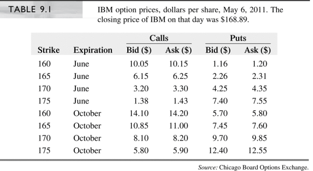

## Put-Call Parity

- Put-call parity is the single most important relationship among option prices
- The basic relationship for European options is

$$\begin{eqnarray}
C(K,T) - P(K,T) &=& PV_{0,T}(F_{0,T} - K) \\
&=& e^{-rT} (F_{0,T} - K)
\end{eqnarray}$$

- $C(K,T)$ is the price of a European call with strike price $K$ and time to expiry $T$
- $P(K,T)$ is the price of a European put with strike price $K$ and time to expiry $T$
- NB: $e^{-rT} F_{0,T}$ is the prepaid forward price and $e^{-rT} K$ is the prepaid forward price for the strike, so we can think of parity in terms of prepaid forward prices

## Put-Call Parity Continued

- Intuition: buying a call and selling a put with strike price equal to the forward price $(F_{0,T} = K)$ creates a synthetic forward contract, hence must have zero price
- A synthetic long forward position at a price lower than the forward price will cost $PV_{0,T}(F_{0,T} - K)$ since this is the benefit of buying the asset at the strike price rather than the forward price
- Parity generally fails for American-style options, which may be exercised prior to maturity
- There are some general parity bounds for American options (see Appendix 9.A)

## Options on Stock

- The parity relation for options on stock is

$$C(K,T) = P(K,T) + [S_{0} - PV_{0,T}(Div)] - e^{-rT}K$$

- NB: $S_{0}$ is the current spot price of the stock, and $DIV$ is the stream of dividends paid on the stock
- For index options we can write

$$C(K,T) = P(K,T) + S_{0}e^{-\delta T} - e^{-rT}K$$

## Example 9.1

Suppose the following:

- the price of a non-dividend-paying stock is $\$40$
- the continuously compounded interest rate is $8\%$
- the options have an expiry of 3 months
- A $40$-strike European call sells for $\$2.78$ and a $40$-strike European put sells for $\$1.99$
- This is confirmed by put-call parity

$$\$2.78 = \$1.99 + \$40 - \$40e^{-0.08 \times 0.25}$$

## Example 9.2

Make the same assumptions as in Example 9.1 except that the stock pays a $\$5$ dividend just prior to expiration

- The European call option is $\$0.74$
- The European put option is $\$4.85$

These prices satisfy put-call parity for a stock with dividends

$$\$0.74 - \$4.85 = (\$40 - \$5e^{-0.08 \times 0.25}) - \$40e^{-0.08 \times 0.25}$$

## Synthetic Stock

- Given the parity relationship, we have a cookbook for the synthetic creations of options, stocks, and T-bills
- Solving for the stock price we have

$$S_{0} = C(K,T) - P(K,T) + PV_{0,T}(Div) + e^{-rT}K$$

- Buying the call, selling the put, and lending the present value of the strike and dividends synthetically replicates the stock

## Synthetic T-bills

- If we buy the stock, sell the call, and buy the put, we have purchased the stock and short-sold the synthetic stock
- This transaction gives us a hedged position with zero risk
- It did, however, require initial investment
- Parity shows the following:

$$S_{0} + P(K,T) - C(K,T) = PV_{0,T}(K) + PV_{0,T}(Div)$$

- This position costs $PV_{0,T}(K) + PV_{0,T}(Div)$ and pays $K + FV_{0,T}(Div)$ at expiry
- This is a synthetic T-bill (called a conversion)
- Likewise we can create a short T-bill position (called a reverse conversion)

## Synthetic Options

- Parity tells us that

$$C(K,T) = S_{0} - PV_{0,T}(Div) - PV_{0,T}(K) + P(K,T)$$

- And also that

$$P(K,T) = C(K,T) - S_{0} + PV_{0,T}(Div) + PV_{0,T}(K) +$$

- This gives us a hint about how to statically hedge an option

# 9.3 Comparing Options with Respect to Style, Maturity, and Strike

## European versus American Options

- Since an American option can be exercised at anytime, whereas a European option can only be exercised at expiration, an American option must always be at least as valuable as an otherwise identical European option

$$\begin{align}
C_{Amer}(S,K,T) & \ge C_{Eur}(S,K,T) \\
P_{Amer}(S,K,T) & \ge P_{Eur}(S,K,T)
\end{align}$$

## Maximum and Minimum Option Prices

- Call price cannot
  - be negative
  - exceed stock price
  - be less than price implied by put-call parity using zero for put price:

$$S > C_{Amer}(S,K,T) \ge C_{Eur}(S,K,T) \ge \max{[0, PV_{0,T}(F_{0,T}) - PV_{0,T}(K)]}$$

- Put price cannot
  - be more then the strike price
  - be less than price implied by put-call parity using zero for put price

$$K > P_{Amer}(S,K,T) \ge P_{Eur}(S,K,T) \ge \max{[0, PV_{0,T}(K) - PV_{0,T}(F_{0,T})]}$$

## Early Exercise for American Options

- An American call option on a non-dividend-paying stock should not be exercised early, because

$$C_{Amer} \ge C_{Eur} \ge S_{T} - K$$

- That means, one would lose money by exercising early instead of selling the option
- If there are dividends, it may be optimal to exercise early, just prior to a dividend
- It may be optimal to exercise a non-dividend-paying put option early if the underlying stock price is sufficiently low

## Time to Expiration

- An American option (both put and call) with more time to expiration is at least as valuable as an American option with less time to expiration. This is because the longer option can easily be converted into a shorter option by exercising it early
- A European call option on a non-dividend-paying stock will be more valuable than an otherwise identical option with less time to expiration
- European call options on dividend-paying stock and European puts may be less valuable than an otherwise identical option with less time to expiration
- When the strike price grows at the rate of interest, European call and put prices on a non-dividend-paying stock increases with time to maturity

## Different Strike Prices

Different strike prices $(K_{1} < K_{2} < K_{3})$, for both European and American options

- A call with a low strike price is at least as valuable as an otherwise identical call with a higher strike price. $C(K_{1}) \ge C(K_{2})$
- A put with a high strike price is at least as valuable as an otherwise identical put with a lower strike price. $P(K_{2}) \ge P(K_{1})$
- The premium difference between otherwise identical calls with different strike prices cannot be greater than the difference in strike prices. $C(K_{1}) - C(K_{2}) \le K_{2} - K_{1}$

## Different Strike Prices Continued

Different strike prices $(K_{1} < K_{2} < K_{3})$, for both European and American options

- The premium difference between otherwise identical puts with different strike prices cannot be greater than the difference in strike prices. $P(K_{1}) - P(K_{2}) \le K_{2} - K_{1}$
- Premiums decline at a decreasing rate for calls with progressively higher strike prices. (Convexity of option price with respect to strike price)

$$\frac{C(K_{1}) - C(K_{2})}{K_{2} - K_{1}} \le \frac{C(K_{2}) - C(K_{3})}{K_{3} - K_{2}}$$